# PML Project

Matthew Guschwan

October 24, 2015

```r
## Needed packages
library(caret)
library(randomForest)
```

```r
library(rpart)
library(rpart.plot)
library(e1071)
library(rattle)   ### needed in final version?
```

# Decision Tree

I chose random forest algorithms because of their power to identify variables that influence outcomes.

set the seed for the sake of reproducibility

```r
set.seed(42)
```

load the data with NA (if necessary setwd() “~/datasciencecoursera/PML Machine Learning”, list.files)

```r
trainUrl <- "http://d396qusza40orc.cloudfront.net/predmachlearn/pml-training.csv"
testUrl <- "http://d396qusza40orc.cloudfront.net/predmachlearn/pml-testing.csv"

trainSet <- read.csv(url(trainUrl), na.strings=c("NA","#DIV/0!", ""))
testSet <- read.csv(url(testUrl), na.strings=c("NA","#DIV/0!", ""))
```

# Clean the data

Delete columns with all missing values  
When you divide by 0 (zero) or a blank cell, Microsoft Excel displays the error value “#DIV/0!” as the result of the calculation. (wikipedia.org)

```r
trainSet<-trainSet[,colSums(is.na(trainSet)) == 0]
testSet <-testSet[,colSums(is.na(testSet)) == 0]
```

Get rid of first few columns as they are not relevant data. - user name, timestamps and windows are not useful as far as I can tell, for this project.

```r
trainSet   <- trainSet[,-c(1:7)]
testSet <- testSet[,-c(1:7)]
```

plot the ‘classe’ variable to get relative values

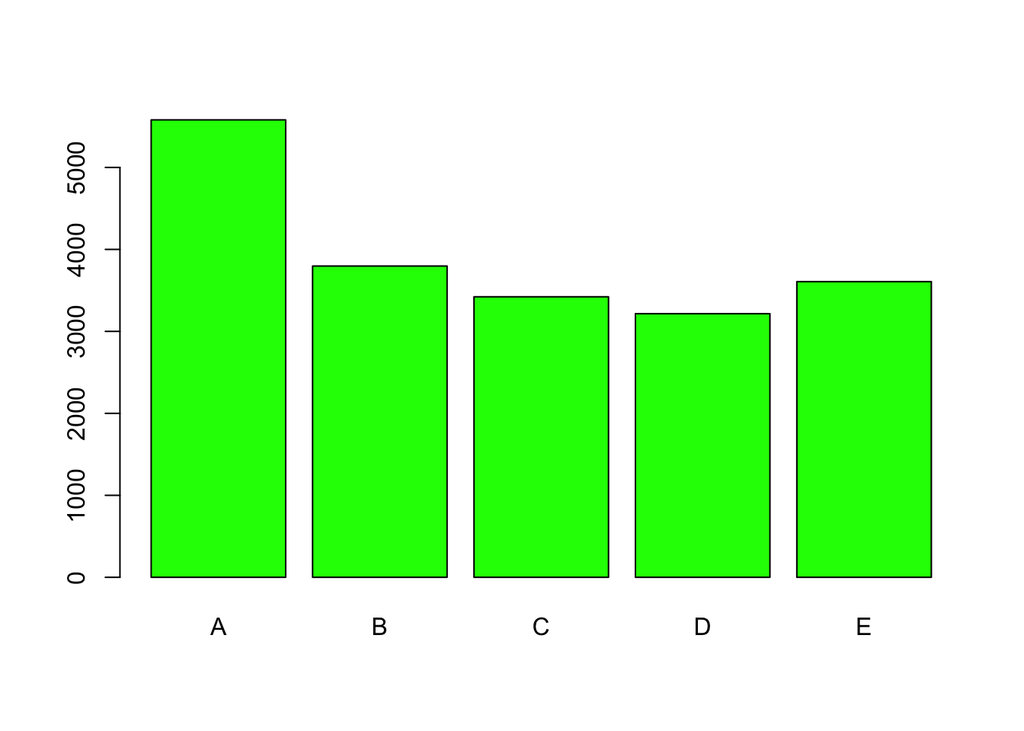

```r
plot(trainSet$classe, col="green")
```

Since the test set is relatively small, I will partition the train set into two groups.

```r
subTrainTest <- createDataPartition(y=trainSet$classe, p=0.75, list=FALSE)
subTrain <- trainSet[subTrainTest, ]
subTest <- trainSet[-subTrainTest, ]
```

second plot of ‘classe’ shows same relative proportions to larger trainSet

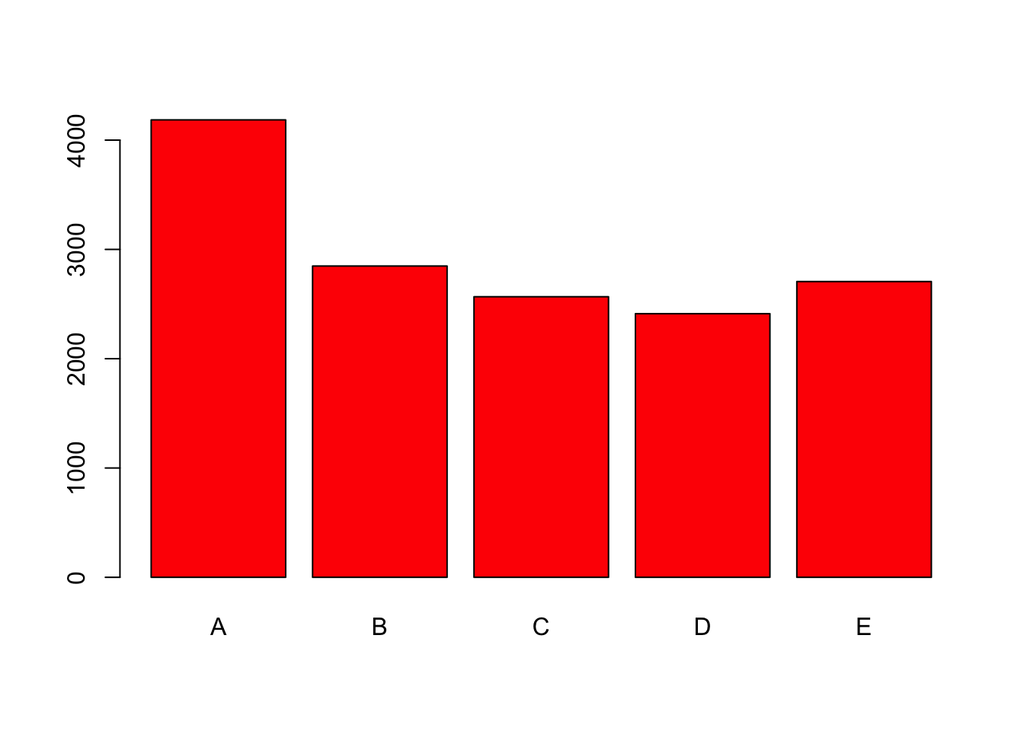

```r
plot(subTrain$classe, col="red")
```

first model using Decision Tree

```r
modelDT <- rpart(classe ~ ., data=subTrain, method="class")
```

prediction from model1

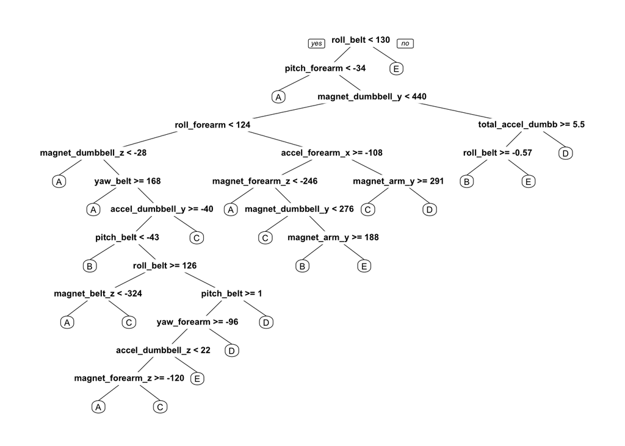

```r
predictionDT <- predict(modelDT, subTest, type = "class")
# plot the decision tree
rpart.plot(modelDT)
```